```python
# Load libraries
import numpy as np
import pandas as pd
from sklearn.tree import DecisionTreeRegressor
from sklearn.tree import DecisionTreeClassifier
from sklearn.model_selection import GridSearchCV, cross_val_score
from sklearn.preprocessing import LabelEncoder
from sklearn.ensemble import RandomForestClassifier
from sklearn.ensemble import RandomForestRegressor
from sklearn.metrics  import  mean_squared_error as mse
from sklearn.ensemble import AdaBoostRegressor
from sklearn.ensemble import AdaBoostClassifier
from sklearn import metrics
import matplotlib.pyplot as plt
from collections import Counter
from matplotlib import cm
from sklearn import datasets
from sklearn.metrics import confusion_matrix
from sklearn.neighbors import KNeighborsClassifier
from sklearn.model_selection import train_test_split
import seaborn as sns
from sklearn.cluster import KMeans
from scipy.spatial.distance import cdist
from sklearn.decomposition import PCA
import networkx as nx
from community import best_partition
import scipy.cluster.hierarchy as sch
from sklearn.cluster import AgglomerativeClustering
import math
import re

# Our Data Files:
# HW2_ML\\index.xlsx - the indexes which the settlments details affect from - features we will use and add to our election votes data
# HW2_ML\\Election21_With_Index_Features.xlsx - votes in each settlment in election 21
# HW2_ML\\Election22_With_Index_Features.xlsx - votes in each settlment in election 22
# HW2_ML\\Election23_With_Index_Features.xlsx - total votes in election 23 to each party and added here the indexes we use in the avg of 21 + 22 file
# HW2_ML\\Election23_With_Booths.xlsx - Booths votes in each settlment in election 23
# HW2_ML\\Election21_22_AVG_With_Index_Features.xlsx  - votes avg in eac settlments from election 21 + 22 and added here the relevant indexes
# HW2_ML\\Election21_22_23_AVG_With_Index_Features.xlsx  - votes avg in eac settlments from election 21 + 22 + 23 and added here the relevant indexes
```

# Methods we use more then once

```python
# Set random seed to ensure reproducible runs
RSEED = 50

# method to transform all categorialfeatures
def transformCategoricalFeatures1(df):
    k = list(df.columns)
    count = 0
    for column in df.columns:
        if isinstance(df[column].unique()[0], str):
            y = df[column].unique()
            encode = LabelEncoder()
            encode.fit(df[column].astype(str))
            df[column] = encode.transform(df[column].astype(str))
            x = df[column].unique()

# methods to reverse the words in hebrew so we can read them correctly
def reverse(string):
    string = "".join(reversed(string))
    return string
def dffeaturesReverse(df):
    features=[]
    for i in df.columns:
        features.append(reverse(i))
    df.columns = features
    return df

# we check if the ratio is more the the "Raf". if yes meaning we need suppervision else we dont need
def ChecksuperviseNeeded(df):
    superviseNeeded=[]
    for votes, pasol in zip(df["מצביעים"],df["פסולים"]) :
        if pasol / votes > 0.005:
            superviseNeeded.append(1)
        else:
            superviseNeeded.append(0)
    return superviseNeeded

# calcuatin each settlment his ratio between voters and invalid votes.
def calculateRatio(df):
    finalRatio = []
    for votes, Hizoypasol in zip(df["מצביעים"],df["פסולים"]) :
        finalRatio.append(Hizoypasol / math.sqrt(votes))
    df["יחס סופי"] = finalRatio
    df = df.sort_values(by=['יחס סופי'], ascending = False)
    return df

# each election have his own raf so we will check if the ratio is above that raf or not
def supervisionNeed(df, raf):
    superviseNeeded=[]
    for ratio in df["יחס סופי"] :
        if ratio > raf:
            superviseNeeded.append(1)
        else:
            superviseNeeded.append(0)
    df["פיקוח"] = superviseNeeded
```

# Question 2 - Data description

In this Question we will show the data of Israeli settlments and the 21st, 22nd and 23rd elecion results.

### Largest 20 Settelments in Israel

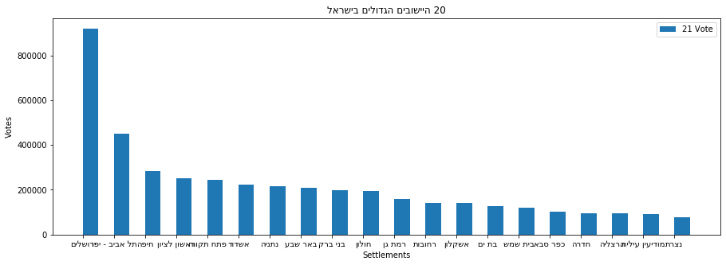

```python
# settelments details
dfSettelmentsDetails = pd.read_excel("HW2_ML\\ElectionData\\Election21_22_AVG_With_Index_Features.xlsx")
dfsortedCities = dfSettelmentsDetails.sort_values(by=['סך הכל אוכלוסייה 2018'], ascending = False)
dfsortedCities1 = dfsortedCities.iloc[:,[0,4]].head(20)

plt.rcParams["figure.figsize"] = (15,5)
political_partyV21=[]
for i in dfsortedCities1.iloc[:,0]:
    political_partyV21.append(reverse(i))
ScoreV21 = list(dfsortedCities1.iloc[:,1])

plt.title('לארשיב םילודגה םיבושייה 20')
plt.xlabel('Settlements')
plt.ylabel('Votes')
plt.grid(linestyle=" ")
plt.xticks(range(0,20), political_partyV21)
plt.bar(political_partyV21, ScoreV21,  width=0.50, label = '21 Vote', align='edge')
plt.legend(loc = 'upper right')
plt.show()
```

```python
settlements = pd.read_excel("HW2_ML\\ElectionData\\setelmant.xlsx")
settlements = pd.DataFrame(settlements.iloc[-1,8:12])
settlements
```

|  | 1214 |
| --- | --- |
| סך הכל אוכלוסייה 2018 | 8853904 |
| יהודים ואחרים | 7049003 |
| מזה: יהודים | 6630280 |
| ערבים | 1804901 |

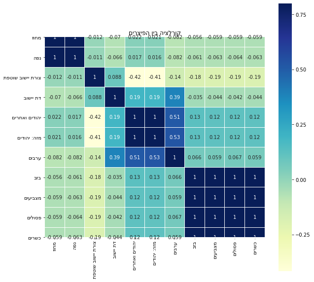

```python
df = dfSettelmentsDetails.iloc[:,[1,2,3,5,6,7,8,9,10,11,12]]
df = dffeaturesReverse(df)
corr=df.corr()
plt.figure(figsize=(10, 10))

sns.heatmap(corr, vmax=.8, linewidths=0.01,
            square=True,annot=True,cmap='YlGnBu',linecolor="white")
plt.title('םירציפה ןיב היצלרוק');
```

##### Features and data explanation:

Our data have 1210 rows for the number of settlments. Each data set have row number 1211 which is the sum of the settlments votes for each party, number of population, number of voters, invalid and valid vvotes. We have 3 diffrent data sets, 1 for each election which hold the total amput of the votes for each party and the demoghraphic features for each settlmet. Moreover we created 2 data sets which hold the avg of electin 21+22 and hold the avf of election 21+22+23. the avg is only on the votes per each party. this way we can check what the majority from out population ad voters voted in 3 or 2 diffrent elections.

Each dataset hold the following features:

1) District - each settlement ascribe to diffrent district. In israel there are 7 different.

2) Napa - small area inside the district. each district have number of napas.

3) Settlement form - each city have his own form. In Israel there are number of different forms.

4) settlement religious - We have Jewish, Arabs, durozi and other religious. each settlement have his own.

5) Jewish and others - the number of the Jewish and other religion in spcific settlement.

6) Jewish - the number of the Jewish in spcific settlement.

7) Arabs - the number of the Arabs in spcific settlement.

8) voters - The number from the population who can vote in election

9) voted - the number of the people who voted in te election

10) invalid - the number of voted which invalif from the total amount of voters in the election

11) Valid - valid votes from the entire voters in the election.

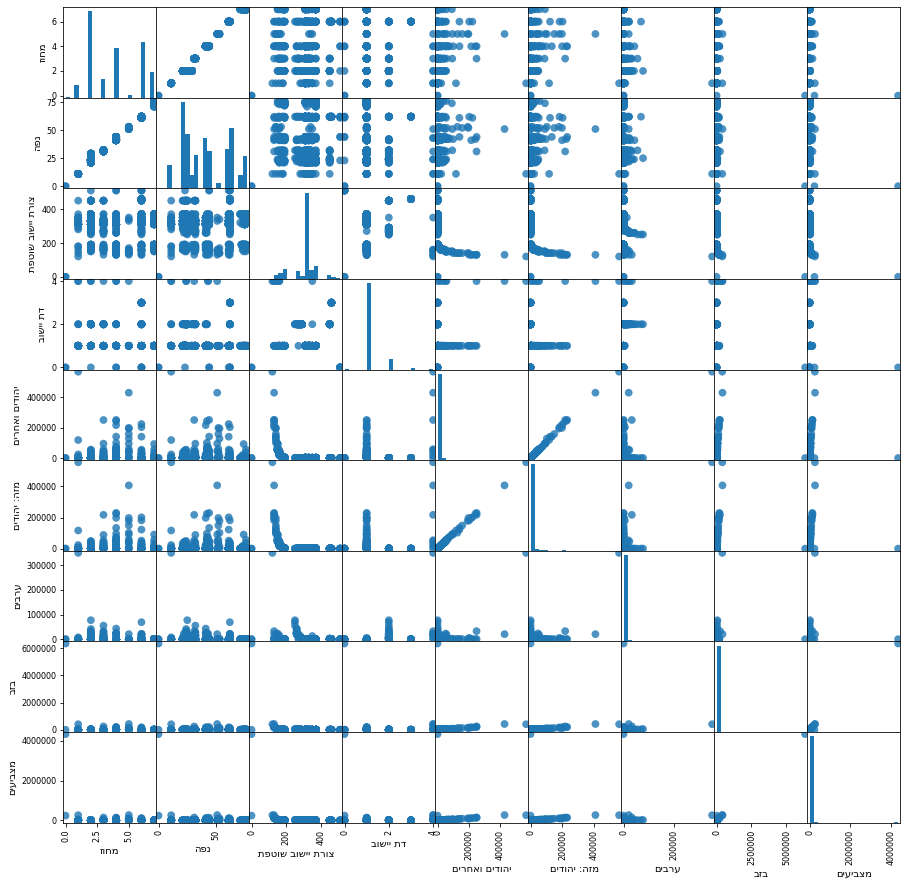

```python
df = dfSettelmentsDetails.iloc[:,[1, 2,3,5,6,7,8,9,10]]
df = dffeaturesReverse(df)

pd.plotting.scatter_matrix(df, figsize=(15, 15),
                           marker='o', hist_kwds={'bins': 20}, s=60,
                           alpha=.8)

plt.show()
```

## Elections Results:

In each election 21, 22 and 23 we will show and calculate the following:

- Number of voters, valid and invalid votes
- Largest parties which passed votes threshold
- We calculate for each party the number of seats in the Kneset
- Show the % of the party from the entire votings.

## Election 21st - results

### Biggest Parties:

In this section we will see the final results for Election 21st in Israel. We can find the largest parties in this election and the distribution.

- Mahal - Likud party
- Pha - Blue & White party
- Shass - shas party
- Gimel - United Thora party
- Vam - Arab party
- Emet - Emet party
- Lamed - Israel Beytenu
- Tov - Yamina party
- Meretz - Meretz party
- Kaf - Kolano party
- Da'am - Arab party

```python
dfVote21 = pd.read_excel("HW2_ML\\ElectionData\\Election21_With_Index_Features.xlsx")
df21Finale = pd.DataFrame(dfVote21.iloc[-1,1:5]).transpose()
x21 =  dfVote21.rename(columns={"בזב": "בעלי זכות בחירה"})
x21 = x21[['פסולים','כשרים','מצביעים','בעלי זכות בחירה']]

# we save the total valid voted to getthe kneset seat bar
votersValid21 = x21.iloc[-1,1]
votersValid21 = votersValid21 / 120

v21 = x21.iloc[-1,:]
v21
```

```
פסולים               30605
כשרים              4287079
מצביעים            4317316
בעלי זכות בחירה    6299338
Name: 1210, dtype: int64
```

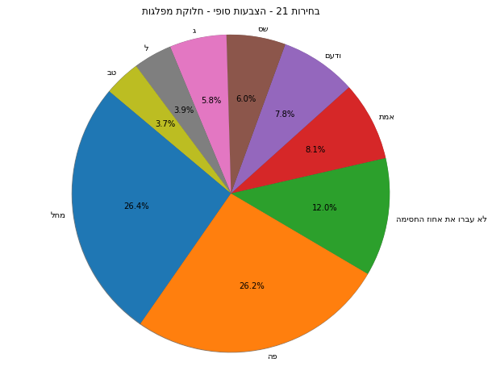

|  | כמות קולות | כמות מנדטים |
| --- | --- | --- |
| מחל | 1133864 | 31 |
| פה | 1123016 | 31 |
| לא עברו את אחוז החסימה | 516405 | 14 |
| אמת | 346243 | 9 |
| ודעם | 333842 | 9 |
| שס | 257961 | 7 |
| ג | 248702 | 6 |
| ל | 168574 | 4 |
| טב | 158472 | 4 |

```python
# we createa graph to show tthe biggest parties the distribution affect of each party
# sort the prtys from largets to smallest
dfsortedMiflagotV21 = dfVote21.iloc[:,13:22].sort_values(by=1210, axis=1, ascending=False)
dfsortedMiflagotScoreV21 = dfsortedMiflagotV21.iloc[-1,:]

plt.rcParams["figure.figsize"] = (15,5)
dfsortedMiflagotV21 = dffeaturesReverse(dfsortedMiflagotV21)
ScoreV21 = list(dfsortedMiflagotScoreV21)

#plot show the distribution
labels = dfsortedMiflagotV21.columns
sizes = list(dfsortedMiflagotScoreV21)
cmap = plt.cm.prism
colors = cmap(np.linspace(0., 1., len(labels)))
fig = plt.figure(figsize=[10, 8])
plt.pie(sizes,radius = 10 ,labels=labels, autopct='%1.1f%%', shadow=True, startangle=140, labeldistance=1.05)
plt.title('תוגלפמ תקולח - יפוס תועבצה - 21 תוריחב')
plt.axis('equal')
plt.show()

# calculate for each party how many knesetSeats they will get
listMandats21 = []
for i in dfsortedMiflagotScoreV21:
    listMandats21.append(int(i / votersValid21))
listMandats21
electionsV21 = {
             'כמות קולות': dfsortedMiflagotScoreV21,
             'כמות מנדטים': listMandats21
        }
finalResulysWithMandatV21 = pd.DataFrame(electionsV21, columns = ['כמות קולות', 'כמות מנדטים'])
finalResulysWithMandatV21
```

## Election 22nd - results

### Numbers:

- Voters: 4.46mil
- Valid Votes: 4.43mil
- Invalid votes: 28362

### Biggest Parties:

In this section we will see the final results for Election 22nd in Israel. We can find the largest parties in this election and the distribution.

- Pha - Blue & White party
- Mahal - Likud party
- V'Daam - Joint List party
- Shass - Shas party
- Lamed - Israel Beytenu party
- Gimel - United Torha party
- Tov - Yamina party
- Emet - Emet party
- Meretz - Meretz party

```python
dfVote22 = pd.read_excel("HW2_ML\\ElectionData\\Election22_With_Index_Features.xlsx")
df22Finale = pd.DataFrame(dfVote22.iloc[-1,1:5]).transpose()
x22 =  dfVote22.rename(columns={"בזב": "בעלי זכות בחירה"})
x22 = x22[['פסולים','כשרים','מצביעים','בעלי זכות בחירה']]

# we save the total valid voted to get the kneset seat bar
votersValid22 = x22.iloc[-1,1]
votersValid22 = votersValid22 / 120

v22 = x22.iloc[-1,:]
v22
```

```
פסולים               28362
כשרים              4436806
מצביעים            4465168
בעלי זכות בחירה    6391218
Name: 1210, dtype: int64
```

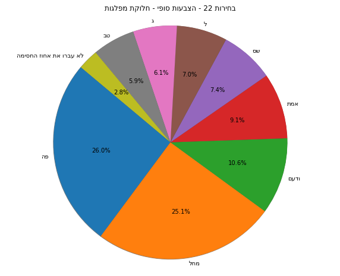

|  | כמות קולות | כמות מנדטים |
| --- | --- | --- |
| פה | 1151214 | 31 |
| מחל | 1113617 | 30 |
| ודעם | 470211 | 12 |
| אמת | 404421 | 10 |
| שס | 330199 | 8 |
| ל | 310154 | 8 |
| ג | 268775 | 7 |
| טב | 260655 | 7 |
| לא עברו את אחוז החסימה | 125897 | 3 |

```python
# we createa graph to show tthe biggest parties the distribution affect of each party
# sort the prtys from largets to smallest
dfsortedMiflagotV22 = dfVote22.iloc[:,13:22].sort_values(by=1210, axis=1, ascending=False)
dfsortedMiflagotScoreV22 = dfsortedMiflagotV22.iloc[-1,:]

plt.rcParams["figure.figsize"] = (15,5)
dfsortedMiflagotV22 = dffeaturesReverse(dfsortedMiflagotV22)
ScoreV22 = list(dfsortedMiflagotScoreV22)

#plot show the distribution
labels = dfsortedMiflagotV22.columns
sizes = list(dfsortedMiflagotScoreV22)
cmap = plt.cm.prism
colors = cmap(np.linspace(0., 1., len(labels)))
fig = plt.figure(figsize=[10, 8])
plt.pie(sizes,radius = 10 ,labels=labels, autopct='%1.1f%%', shadow=True, startangle=140, labeldistance=1.05)
plt.title('תוגלפמ תקולח - יפוס תועבצה - 22 תוריחב')
plt.axis('equal')
plt.show()

# calculate for each party how many knesetSeats they will get
listMandats22 = []
for i in dfsortedMiflagotScoreV22:
    listMandats22.append(int(i / votersValid22))
listMandats22
electionsV22 = {
             'כמות קולות': dfsortedMiflagotScoreV22,
             'כמות מנדטים': listMandats22
        }
finalResulysWithMandatV22 = pd.DataFrame(electionsV22, columns = ['כמות קולות', 'כמות מנדטים'])
finalResulysWithMandatV22
```

## Election 23rd - results

### Numbers:

- Voters: 4.61mil
- Valid Votes: 4.59mil
- Invalid votes: 25073

### Biggest Parties:

In this section we will see the final results for Election 23rd in Israel. We can find the largest parties in this election and the distribution.

- Mahal - Likud party
- Pha - Blue & White party
- V'Daam - Joint List party
- Shass - Shas party
- Gimel - United Thora party
- Emet - Meretz party
- Lamed - Israel Beytenu
- Tov - Yamina party

```python
dfVote23 = pd.read_excel("HW2_ML\\ElectionData\\Election23_With_Index_Features.xlsx")
df23Finale = pd.DataFrame(dfVote23.iloc[-1,1:5]).transpose()
x23 =  dfVote23.rename(columns={"בזב": "בעלי זכות בחירה"})
x23 = x23[['פסולים','כשרים','מצביעים','בעלי זכות בחירה']]

# we save the total valid voted to get the kneset seat bar
votersValid23 = x23.iloc[-1,1]
votersValid23 = votersValid23 / 120

v23 = x23.iloc[-1,:]
v23
```

```
פסולים               25073
כשרים              4590062
מצביעים            4615135
בעלי זכות בחירה    6453255
Name: 1210, dtype: int64
```

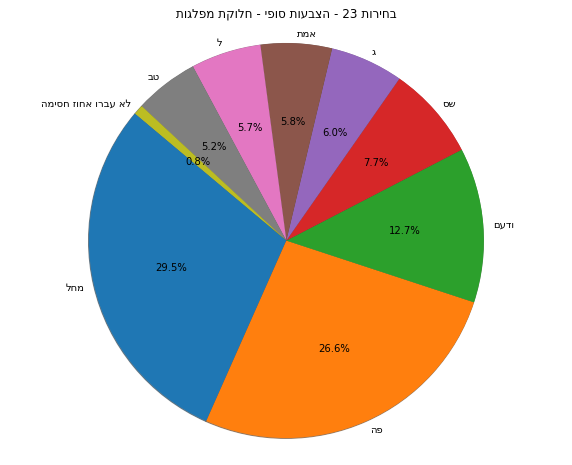

|  | כמות קולות | כמות מנדטים |
| --- | --- | --- |
| מחל | 1352449 | 35 |
| פה | 1220381 | 31 |
| ודעם | 581507 | 15 |
| שס | 352853 | 9 |
| ג | 274437 | 7 |
| אמת | 267480 | 6 |
| ל | 263365 | 6 |
| טב | 240689 | 6 |
| לא עברו אחוז חסימה | 36901 | 0 |

```python
# we createa graph to show tthe biggest parties the distribution affect of each party
# sort the prtys from largets to smallest
dfsortedMiflagotV23 = dfVote23.iloc[:,13:22].sort_values(by=1210, axis=1, ascending=False)
dfsortedMiflagotScoreV23 = dfsortedMiflagotV23.iloc[-1,:]

plt.rcParams["figure.figsize"] = (15,5)
dfsortedMiflagotV23 = dffeaturesReverse(dfsortedMiflagotV23)
ScoreV23 = list(dfsortedMiflagotScoreV23)

#plot show the distribution
labels = dfsortedMiflagotV23.columns
sizes = list(dfsortedMiflagotScoreV23)
cmap = plt.cm.prism
colors = cmap(np.linspace(0., 1., len(labels)))
fig = plt.figure(figsize=[10, 8])
plt.pie(sizes,radius = 10 ,labels=labels, autopct='%1.1f%%', shadow=True, startangle=140, labeldistance=1.05)
plt.title('תוגלפמ תקולח - יפוס תועבצה - 23 תוריחב')
plt.axis('equal')
plt.show()

# calculate for each party how many knesetSeats they will get
listMandats23 = []
for i in dfsortedMiflagotScoreV23:
    listMandats23.append(int(i / votersValid23))
listMandats23
electionsV23 = {
             'כמות קולות': dfsortedMiflagotScoreV23,
             'כמות מנדטים': listMandats23
        }
finalResulysWithMandatV23 = pd.DataFrame(electionsV23, columns = ['כמות קולות', 'כמות מנדטים'])
finalResulysWithMandatV23
```

### show the division of the partys for right, left and center

[output not shown]

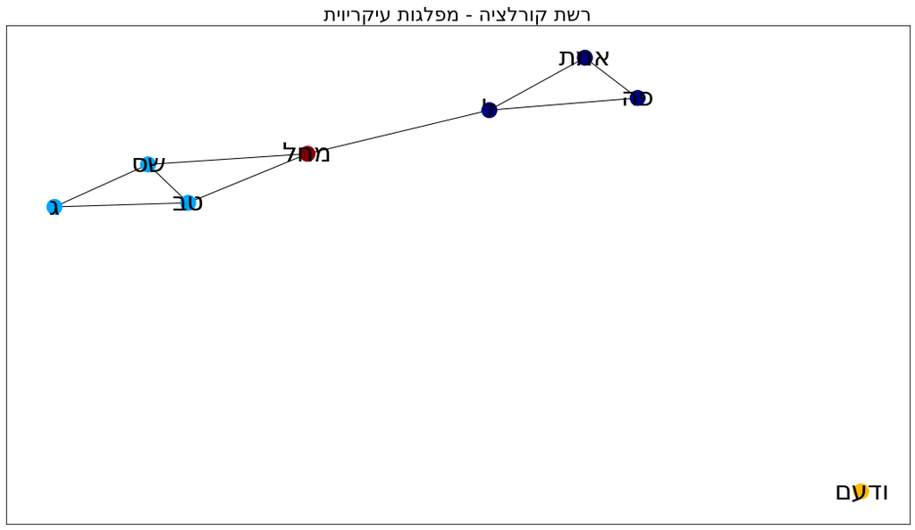

```python
# this matrix corellation we took from KAGGLE WEBSITE and we modified to work with our data.
dfVote23 = dfVote23.iloc[:,13:22]

#create the party sizes normalized
party_sizes = dfVote23.sum().div(dfVote23.sum().sum())
#take the biggest parties - the one who pass the bar
major_parties = party_sizes.index[party_sizes>0.01].to_list()
normalized_votes=dfVote23.div(dfVote23.sum(axis=1), axis=0)

pca=PCA(n_components=2)
major_party_votes=normalized_votes[major_parties]

G=nx.Graph(major_party_votes.corr()>0)
G=nx.relabel_nodes(G,dict(zip(G.nodes(),[x[::-1] for x in major_parties])))
communities=best_partition(G)

community_colors={0:0,1:0.2,2:0.5,3:0.7,4:0.9}
node_coloring=[community_colors[communities[node]] for node in G.nodes()]

nx.pos=nx.fruchterman_reingold_layout(G, dim=2, k=None, pos=None, fixed=None, iterations=5000, weight='weight', scale=1.0, center=None)
nx.draw_networkx(G, cmap=plt.get_cmap('jet'), with_labels=True, node_color=node_coloring,font_size=30)
plt.title('תיוירקיע תוגלפמ - היצלרוק תשר', fontsize=22)
fig = plt.gcf()
fig.set_size_inches(18.5, 10.5)
```

## Total Calculation of 3 Elections - 21, 22, 23

We will show here the diffrences between the last 3 elections in Israel. We check the following:

1. biggest parties from each election and show the diffrences of the votes
2. Valid an invalid votes
3. voters during last 3 elections.
- note: some parties merged during the 21 and 22 election so we merged them to the final name from election 23 (Emet and V'daam party)

### Election Votes comparison

[output not shown]

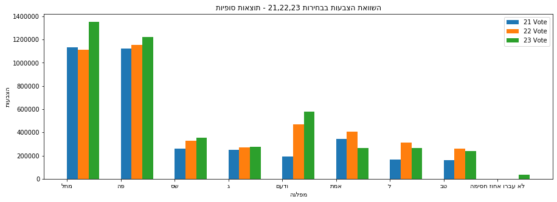

```python
# now we take those 8 parties from above from 3 diffrent elections

# we arrange the data to be in same order so we can make the graphs and show the diffrences
feature_cols_reg21 = ['מחל', 'פה', 'שס', 'ג', 'ום', 'אמת', 'ל', 'טב','לא עברו אחוז חסימה']
feature_cols_reg22_23 = ['מחל', 'פה', 'שס', 'ג', 'ודעם', 'אמת', 'ל', 'טב','לא עברו אחוז חסימה']
dfHigestParties21 = dfVote21.loc[:, feature_cols_reg21]
scoreBestParties21 = dfHigestParties21.iloc[-1,:]
dfHigestParties22 = dfVote22.loc[:, feature_cols_reg22_23]
scoreBestParties22 = dfHigestParties22.iloc[-1,:]
dfHigestParties23 = dfVote23.loc[:, feature_cols_reg22_23]
scoreBestParties23 = dfHigestParties23.iloc[-1,:]

# creating the graph of the biggest parties
x = np.arange(9)
plt.rcParams["figure.figsize"] = (15,5)
political_party=[]
for i in dfHigestParties23.columns:
    political_party.append(reverse(i))

# print(dfsortedMiflagotScoreV21)
v21_bestPartiesScore = list(scoreBestParties21)
v22_bestPartiesScore = list(scoreBestParties22)
v23_bestPartiesScore = list(scoreBestParties23)
plt.title('תויפוס תואצות - 21,22,23 תוריחבב תועבצה תאוושה')
plt.xlabel('הגלפמ')
plt.ylabel('תועבצה')
plt.grid(linestyle=" ")
plt.xticks(range(0,len(political_party)), political_party)
plt.bar(x, v21_bestPartiesScore,  width=0.20, label = '21 Vote', align='edge')
plt.bar(x+ 0.20, v22_bestPartiesScore,  width=0.20, label = '22 Vote', align='edge')
plt.bar(x+0.40, v23_bestPartiesScore,  width=0.20, label = '23 Vote', align='edge')
plt.legend(loc = 'upper right')
plt.show()
```

```python
# Take the features: ['בעלי זכות בחירה', 'מצביעים','כשרים', 'פסולים'] from each election and then show the diffrences.
v21_bestScore = list(x21.iloc[-1,:])
v22_bestScore = list(x22.iloc[-1,:])
v23_bestScore = list(x23.iloc[-1,:])
elections = {'פיצר': ['פסולים', 'כשרים','מצביעים', 'בעלי זכות בחירה'],
             'בחירות 21': list(x21.iloc[-1,:]),
             'בחירות 22': list(x22.iloc[-1,:]),
            'בחירות 23':list(x23.iloc[-1,:])
        }
df = pd.DataFrame(elections, columns = ['פיצר', 'בחירות 21', 'בחירות 22', 'בחירות 23'])
df
```

|  | פיצר | בחירות 21 | בחירות 22 | בחירות 23 |
| --- | --- | --- | --- | --- |
| 0 | פסולים | 30605 | 28362 | 25073 |
| 1 | כשרים | 4287079 | 4436806 | 4590062 |
| 2 | מצביעים | 4317316 | 4465168 | 4615135 |
| 3 | בעלי זכות בחירה | 6299338 | 6391218 | 6453255 |

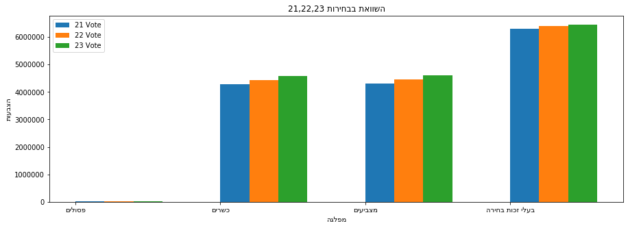

```python
# graph to show the diffrences from 3 elections
criterions=[]
for i in x23.columns:
    criterions.append(reverse(i))
plt.title('21,22,23 תוריחבב תאוושה')
plt.xlabel('הגלפמ')
plt.ylabel('תועבצה')
plt.grid(linestyle=" ")

y = np.arange(4)
plt.xticks(range(0,len(criterions)), criterions)
plt.bar(y, v21_bestScore,  width=0.20, label = '21 Vote', align='edge')
plt.bar(y + 0.20, v22_bestScore,  width=0.20, label = '22 Vote', align='edge')
plt.bar(y + 0.40, v23_bestScore,  width=0.20, label = '23 Vote', align='edge')
plt.legend(loc = 'upper left')
plt.show()
```

# Question 3 - CLUSTERING

### K-MEANS

In K-Means clustering we wil predic to which party the biggest 30 settlments will vote for and which party district 4 votes the most. In each cluster in the model we will check the biggest 3 parties. Becuse we handling with large amount of data - many settlments without duplication we chose to use K-means. This clustering handle better with large data and we dont care about the miss clusiffication this cluster can do. The K-means is very fast model and his running complexity is low. Moreover, because we have a pre-knowledge available on the settlements, for example what district, what form, religious and more features the k-mean can devide them well. Each settelemnt have his own demoghraphic features and the dataset spread very well.

To check the answer we will use the follwing features: Settlement name and all the parties in the election.

- Parts from this section code we took from kaggle website - Israeli election

```python
# data from the 23rd election with booths numbers.
dfSetelments = pd.read_excel("HW2_ML\\ElectionData\\Election23_With_Booths.xlsx")
# drop feature we dont use from our data set
dfSetelments = dfSetelments.drop(dfSetelments.columns[[0,1,3,4,5,6,7,8,9,10]], axis=1)
```

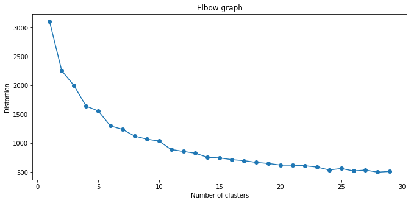

```python
# The biggest settlements
df = dfSetelments.groupby('שם ישוב').sum()
settl_top = df.sum(axis=1).reset_index()
settl_top.columns = ['settlement', 'values']
settl_top = settl_top.sort_values('values', ascending=False)
settl_top['percent'] = round(settl_top['values']/settl_top['values'].sum()*100, 2)

# Optimal number of clusters
distortions = []
K = range(1,30)
for k in K:
    kmeanModel = KMeans(n_clusters=k, max_iter=10000).fit(df)
    kmeanModel.fit(df)
    distortions.append(sum(np.min(cdist(df, kmeanModel.cluster_centers_, 'euclidean'), axis=1)) / df.shape[0])
plt.figure(figsize=(11, 5))
plt.plot(K, distortions, 'o-')
plt.xlabel('Number of clusters')
plt.ylabel('Distortion')
plt.title('Elbow graph')
plt.show()
```

```python
# Сluster analysis (k-means)
kmeanModel = KMeans(n_clusters=5, max_iter=10000).fit(df)
df_clusts = pd.DataFrame({'ID': df.index, 'clusters': kmeanModel.labels_})

# Add Clusters to DF
df = pd.merge(df, df_clusts, right_on='ID', left_index=True)
```

```python
import re
# # Add top paties in each cluster
data = df.drop('ID', axis=1)
data = data.groupby('clusters').sum()

for i in data.index:
    data.iloc[i,:] = round(data.iloc[i,:]/data.iloc[i,:].sum()*100, 2).tolist()

# create new dataframe with the clusters anf the parties included inside that cluster
data1 = pd.DataFrame({'clusters': data.index,
                     'party': str(data.index)})
# adding the name and the % of the largest 3 parties % in the cluster
for i in data.index:
    reg = re.sub(' {2,}', ' - ', str(data.iloc[i,:].sort_values(ascending=False)[0:3]))
    reg = re.sub('\n', ', ', reg)
    reg = re.sub(', Name:.*', '', reg)
    data1.iloc[i,1] = reg
data = data1
del data1
data
```

|  | clusters | party |
| --- | --- | --- |
| 0 | 0 | ודעם - 32.20, פה - 21.15, מחל - 20.41 |
| 1 | 1 | מחל - 38.06, פה - 28.70, ל - 10.06 |
| 2 | 2 | פה - 38.07, מחל - 27.81, אמת - 10.58 |
| 3 | 3 | מחל - 35.34, פה - 29.43, שס - 8.84 |
| 4 | 4 | מחל - 27.75, ג - 24.38, שס - 17.07 |

```python
# Add from the top 20 settlments to each cluster the included inside
data['cities'] = 'text'
topSettlements = df[['ID', 'clusters']]
topSettlements.index = topSettlements.pop('ID')
topSettlements = topSettlements.filter(items=settl_top.head(30).settlement.tolist(), axis=0).reset_index()
for i in set(data.clusters):
    reg = ', '.join(topSettlements.ID[topSettlements.clusters == i])
    data.loc[i,'cities'] = reg

# Add number of all cities in each cluster
data = pd.merge(data, df.groupby('clusters')['ID'].count().reset_index())
data = data.drop(['clusters','ID'], axis=1)
data.columns = [' 5 המפלגות הגדולות בכל קלאסטר',
                'היישובים הגדולים בכל קלאסטר']

data
```

|  | 5 המפלגות הגדולות בכל קלאסטר | היישובים הגדולים בכל קלאסטר |
| --- | --- | --- |
| 0 | ודעם - 32.20, פה - 21.15, מחל - 20.41 | נצרת |
| 1 | מחל - 38.06, פה - 28.70, ל - 10.06 | חיפה, ראשון לציון, פתח תקווה, אשדוד, נתניה, חו... |
| 2 | פה - 38.07, מחל - 27.81, אמת - 10.58 | מעטפות חיצוניות, תל אביב יפו |
| 3 | מחל - 35.34, פה - 29.43, שס - 8.84 | בני ברק, בת ים, כפר סבא, הרצליה, חדרה, מודיעין... |
| 4 | מחל - 27.75, ג - 24.38, שס - 17.07 | ירושלים |

```python
# after checking the settlements vote, we will use the data to check district votes and which party the district vote the most.
settlementFromCluster = list(topSettlements.ID)
election23Features = pd.read_excel("HW2_ML\\ElectionData\\Election23_With_Index_Features.xlsx")
dfSetelmentsBeforeDrop = election23Features[election23Features['שם ישוב'].isin(settlementFromCluster)]
# We checked which district have the most settlements from top 30 and we figured its district number 4
print(dfSetelmentsBeforeDrop['מחוז'].value_counts())

district4 = dfSetelmentsBeforeDrop.loc[dfSetelmentsBeforeDrop['מחוז'] == 4]
partyName = district4.iloc[:,13:].idxmax(axis=1).mode()
print("\nIn largest 30 settlements in Israel, The most belong to District CENTER (4) and vote the most to: ", partyName[0])

district5 = dfSetelmentsBeforeDrop.loc[dfSetelmentsBeforeDrop['מחוז'] == 5]
partyName = district5.iloc[:,13:].idxmax(axis=1).mode()
print("District Tel-Aviv (5) vote the most to: ", partyName[0])

district6 = dfSetelmentsBeforeDrop.loc[dfSetelmentsBeforeDrop['מחוז'] == 6]
partyName = district6.iloc[:,13:].idxmax(axis=1).mode()
print("District SOUTH (6) vote the most to: ", partyName[0])
```

```
4    11
5     7
6     4
3     3
2     2
1     2
0     1
Name: מחוז, dtype: int64

In largest 30 settlements in Israel, The most belong to District CENTER (4) and vote the most to:  מחל
District Tel-Aviv (5) vote the most to:  פה
District SOUTH (6) vote the most to:  מחל
```

#### K-MEANS Results:

```
- we can see that Mahal (Likud party) and Pha (Blue & White party) parties are the major parties in the entire top settlements.
- we can see that TEL-AVIV vote the most to PHA (Blue & White party) and Jerusalem vote the most to Mahal (Likud party)
- The Arab settelment - Nazarath vote the most to VAD'AAM (Joint List party). We will take that as a sample that all arab settelements vote the most to Joint List party
- We can see the the booth workers vote the most to PHA (Blue & White party) party (outside envelopes)
- District number center (4) and south (6) Vote the most to Likud party whereas district Tel-Aviv(5) vote to Blue & White party.
```

## Hierarchical Clustering

- In Hierarchical cluster we took the data set which hold the avg votes from the last 3 elections.
- Each party column holds the avg from the 3 election. In the data we use, we created new features which holds the party who got the most votes in each settelement and a eature hold the the majority from 3 election voted for this party.
- In this cluster method we will predict the settelements forms voting. We will take a specific form and try to check and predict which party they vote for.
- For the specific settelement form we will check how many settelements we have from our enetire datset.
- We will use the following features: settlement form and the majority voters (בחירות מאוחד)
- We chose to use hirarchical becuase 'settelemnt form' feature is a small data and Hierarchical clustering preforme well with small data. this cluster is easy to implement.
- Due to predicting settelements form we dont need to know the K before we doing this cluster method. Due to that, we will gain the privilage to choose which K we want.

```python
# here we use the same data frame but 1 we will change and the other we will keep the same so we can take the relevant columns from it

dataset = pd.read_excel('HW2_ML\\ElectionData\\Election21_22_23_AVG_With_Index_Features.xlsx')
dataset = dataset.drop(['ז','זך','זץ','י','יז','ינ','יף','יק','יר','כ','כן','נ','נז','ני','נץ','נק',"בחירות 21","בחירות 22","בחירות 23",'ףז','ץ','ק','קי','קך','קץ'],axis = 1)
dataset.drop(dataset.tail(1).index,inplace=True)

datasetForUse = pd.read_excel('HW2_ML\\ElectionData\\Election21_22_23_AVG_With_Index_Features.xlsx')
datasetForUse = datasetForUse.drop(['ז','זך','זץ','י','יז','ינ','יף','יק','יר','כ','כן','נ','נז','ני','נץ','נק',"בחירות 21","בחירות 22","בחירות 23",'ףז','ץ','ק','קי','קך','קץ'],axis = 1)
datasetForUse.drop(dataset.tail(1).index,inplace=True)
```

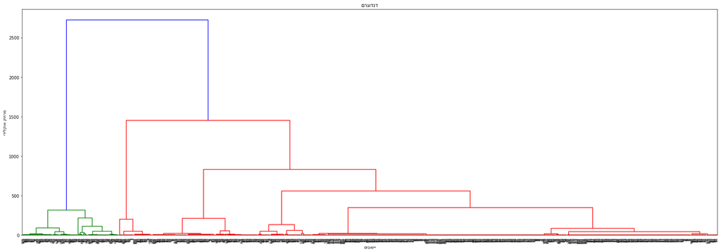

```python
transformCategoricalFeatures1(dataset)

X = np.array(dataset.iloc[:,[3,13]])

plt.figure(figsize = (30,10))
dendrogram = sch.dendrogram(sch.linkage(X, method = 'ward'))

plt.title('םרגודנד')
plt.xlabel('םיבושיי')
plt.ylabel('ידילקוא קחרמ')
plt.show()
```

```python
agg_clustering = AgglomerativeClustering(n_clusters = 6, affinity = 'euclidean', linkage = 'ward')
agg_preds = agg_clustering.fit_predict(X)
datasetForUse["cluster"] = agg_preds

# we take cluster number 5. After checking all the other cluster we found that cluster 5 have only 1 form of settlments so we will analysis that form only
dataset_cust = datasetForUse.loc[datasetForUse['cluster'] == 5]
dataset_cust = dataset_cust.loc[:,["שם ישוב","צורת יישוב שוטפת","בחירות מאוחד"]]
print(dataset_cust['צורת יישוב שוטפת'].value_counts())
```

```
310    402
0        1
Name: צורת יישוב שוטפת, dtype: int64
```

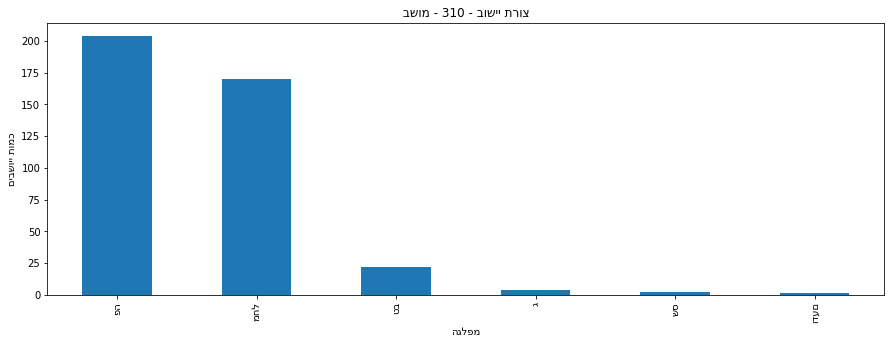

```python
# we will show how many settlments vote for each party.
# We have specific column in our data that calculate each settlment which party he voted  the most in the total of 3 elections.
dataset_cust = dataset_cust.drop(["שם ישוב","צורת יישוב שוטפת"], axis = 1)

# column בחירות מאוחד is the column that show which party got the most votes in each settlments in ou data
pd.value_counts(dataset_cust['בחירות מאוחד']).plot.bar()

plt.title(" בשומ - 310 - בושיי תרוצ ")
plt.xlabel('הגלפמ')
plt.ylabel('םיבשויי תומכ')
plt.show()
```

#### Hierarchical Results:

```
1. We devided our data to 6 cluster. the largest clsuter is number cluster 5.
2. In cluster 5 we can find a specific Yeshuv form - # 310 - Moshav.
3. We learn that 310 have 402 settelement out of 1210 we have in Israel and most of 310 votes for PHA (Blue & White party) and some votes for Mahal (Likud party).
```

# QUESTION 4 - Random Forest

We use Random Forest algoritm to predict the amount of valid votes in 23rd election in the following settlements:

- Haifa
- Ayelet H'shachar
- Eilat
- Shachnin
- Katzerin

To do so, we will use the following features: מחוז, נפה, סה"כ אוכלוסיה, דת ישוב, יהודים ואחרים, מזהה יהודים

###### Workflow:

2) After finding our best features to use in our model, we will train the Random Forest model with 21 and 22 avg election data set and try to predict the column "valid".

3) After getting our best model we will try to predict the valid voted on election 23 dataset.

4) We will show the prediction vs. the real valid votes in election 23 via plot.

```python
# this excel file holds the total votes of the 2 elections calculation and which party each city voted the most.
dataFinal = pd.read_excel('HW2_ML\\ElectionData\\Election21_22_AVG_With_Index_Features.xlsx')
# this excel file hold the sum of votes of each city to each party.
vote23OutPut  = pd.read_excel('HW2_ML\\ElectionData\\Election23_With_Index_Features.xlsx')
```

```python
# we take the settlements before we train the data and removing the from the data frame. we will use them to see the results.

# dataframe g will keep the settelments from vote 23 - settelments as metioned before
specificSettlmentsFromElection23 = vote23OutPut[['שם ישוב','כשרים']].iloc[[59,63,405,866,1031]]
```

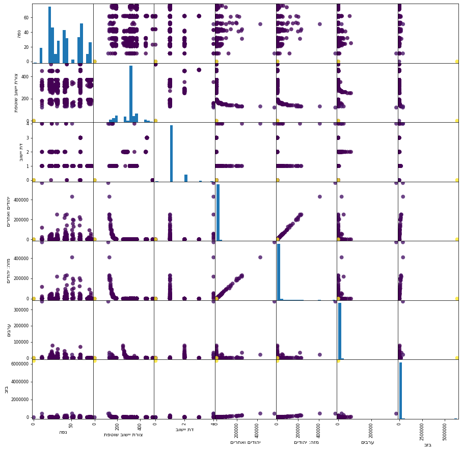

```python
df = dataFinal.iloc[:,[2,3,5,6,7,8,9]]
df = dffeaturesReverse(df)
y =  dataFinal.iloc[:,10]
pd.plotting.scatter_matrix(df, c=y, figsize=(15, 15),
                           marker='o', hist_kwds={'bins': 20}, s=60,
                           alpha=.8)
plt.show()
```

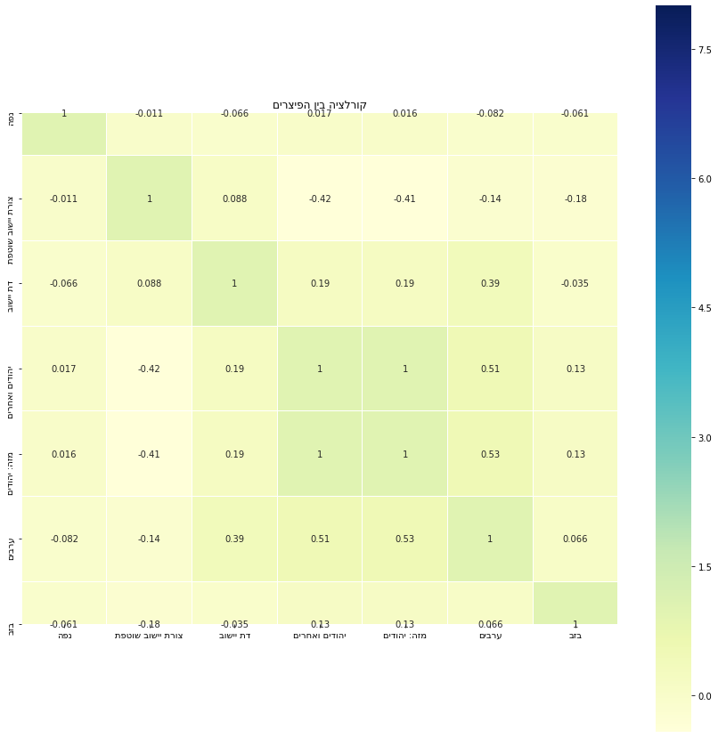

```python
corrMatrix = df.corr()
plt.figure(figsize=(15,15))
sns.heatmap(corrMatrix ,vmax = 8, linewidths = 0.01, square = True, annot = True, cmap="YlGnBu", linecolor="white")
plt.title('םירציפה ןיב היצלרוק');
```

```python
param_grid_forest = {
    'n_estimators': [50], # The number of trees in the forest.
    'max_depth': [None, 5, 9] , # The maximum depth of the tree.
    'max_features': ['sqrt'], # The number of features to consider when looking for the best split
    'min_samples_split': [2, 5, 10], # The minimum number of samples required to split an internal node
    'bootstrap': [True] # Whether bootstrap samples are used when building trees.
}

transformCategoricalFeatures1(dataFinal)
transformCategoricalFeatures1(vote23OutPut)

# מחוז, נפה, סה"כ אוכלוסיה, דת ישוב, יהודים ואחרים, מזהה יהודים
feature_cols_reg = [1,2,4,5,6,7]
# כשרים
feature_target_reg = [12]
# train data 21 + 22
X = dataFinal.iloc[:, feature_cols_reg]
y = dataFinal.iloc[:, feature_target_reg]
trainDataRegressoer, testDataRegressoer, trainTargetRegressoer, testTargetRegressoer = train_test_split(X, y, test_size=0.3, shuffle=True, random_state=1)

# Random Forest
forestRegressor = GridSearchCV(RandomForestRegressor(random_state = RSEED, n_estimators=50), param_grid_forest, cv= 5)
forestRegressor.fit(trainDataRegressoer, trainTargetRegressoer.values.ravel())
best_model_forest_Regressor = forestRegressor.best_estimator_

print("Best parameters:",forestRegressor.best_params_)
prediction_Forest = best_model_forest_Regressor.predict(testDataRegressoer)
print('Random Forest MSE:',mse(testTargetRegressoer,prediction_Forest))
```

```
Best parameters: {'bootstrap': True, 'max_depth': None, 'max_features': 'sqrt', 'min_samples_split': 2, 'n_estimators': 50}
Random Forest MSE: 6610939.640900065
```

[output not shown]

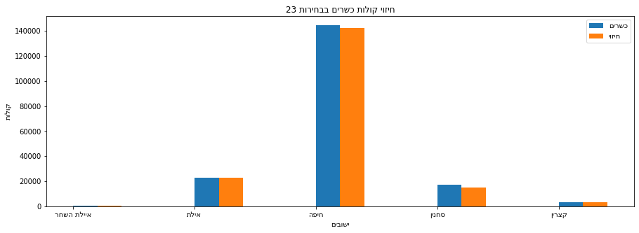

|  | שם ישוב | כשרים | חיזוי קולות כשרים |
| --- | --- | --- | --- |
| 59 | איילת השחר | 585 | 696 |
| 63 | אילת | 22636 | 23043 |
| 405 | חיפה | 144625 | 142424 |
| 866 | סחנין | 17085 | 14925 |
| 1031 | קצרין | 3498 | 3502 |

```python
# we make the prediction on our trained Forest but this time we put election 23 settelments
dflocV23 = vote23OutPut.iloc[[59,63,405,866,1031] , feature_cols_reg]
prediction_Forest = best_model_forest_Regressor.predict(dflocV23)
predictionForestAfterRounding = []
for i in prediction_Forest:
    predictionForestAfterRounding.append(int(round(i)))
scoreHizoy = specificSettlmentsFromElection23["חיזוי קולות כשרים"] = predictionForestAfterRounding
scoreKasher  = specificSettlmentsFromElection23.loc[:, "כשרים"]

# creating the graph with settlements and final votes and prediction voted in election 23
x = np.arange(5)
plt.rcParams["figure.figsize"] = (15,5)
votes=[]
for i in specificSettlmentsFromElection23.iloc[:,0]:
    votes.append(reverse(i))
plt.title('23 תוריחבב םירשכ תולוק יוזיח')
plt.xlabel('םיבושי')
plt.ylabel('תולוק')
plt.grid(linestyle=" ")
plt.xticks(range(0,len(votes)), votes)
plt.bar(x, list(scoreKasher),  width=0.20, label = 'םירשכ', align='edge')
plt.bar(x+ 0.20, list(scoreHizoy),  width=0.20, label = 'יוזיח', align='edge')
plt.legend(loc = 'upper right')
plt.show()

specificSettlmentsFromElection23
```

# Question 5 - ADABOOST

- check prediction Time: 1 week before election 23.
- plot comparition Time: 1 day after the election 23.

In this section we will use ADABOOST to predict the numbers of voters to:

- Mahal - Likud party
- Pha - Blue & White party
- Reshima meshotefet - V'adaam - Joint List party

Our pprediction will consentrate on the following settelments:

- Jerusalem
- Bnei Barak
- Shachnin
- Karmiel
- Dalyat el carmel

In this section we will train our adaboost on election 21 and test the model on election 22, after that we will fit the new model on the avg of the votes between election 21 and election 22. we will try to predict election 23 votes for each partywith the model.

To do so, we will use diffrent features in each model.

###### Workflow:

1) Firstly, we searched for the best featured we want to use to predict the number of voters in each settlement to each party. features:

[output not shown]

- becuase we predict a future election results we cant use features that have direct coralletion for number of voters and valin or invalid feature.

2) After finding our best features to predict the vote to use in our model, we will train the Adaboost model with election 21 data set with the relevant features and test our model with the election 22 dataset and after doing that we will train agan our model with the 21+22 avg dataset to get better prediction. With this way we will get better and aqurate results to predict in election 23.

3) After we trained and optimized our model we will predict the number of voted to each party in each settlement.

4) We will show the prediction vs. the real voters for each party and the same settlements via a comparition plot.

```python
# this excel file holds the total votes of the 2 elections calculation and which party each city voted the most.
dataFinalAdaboost = pd.read_excel('HW2_ML\\ElectionData\\Election21_22_AVG_With_Index_Features.xlsx')

# the 3 excel file hold the sum of votes of each city to each party from election 21,22,23.
vote21Adaboost  = pd.read_excel('HW2_ML\\ElectionData\\Election21_With_Index_Features.xlsx')
vote22Adaboost  = pd.read_excel('HW2_ML\\ElectionData\\Election22_With_Index_Features.xlsx')
vote23Adaboost  = pd.read_excel('HW2_ML\\ElectionData\\Election23_With_Index_Features.xlsx')
```

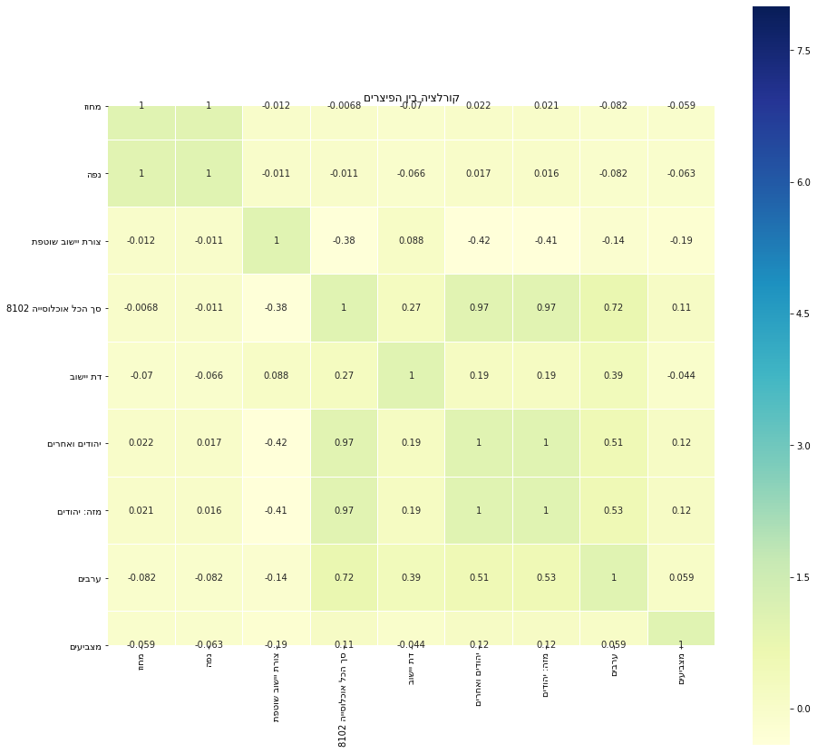

```python
dfFeatures = dataFinalAdaboost.iloc[:, [1,2,3,4,5,6,7,8,10]]

dfFeatures = dffeaturesReverse(dfFeatures)
corrMatrix = dfFeatures.corr()
plt.figure(figsize=(15,15))
sns.heatmap(corrMatrix ,vmax = 8, linewidths = 0.01, square = True, annot = True, cmap="YlGnBu", linecolor="white")
plt.title('םירציפה ןיב היצלרוק');
```

```python
# we take the 3 parties we want to make the model on them and we take the right settelments.
likod = vote23Adaboost[['שם ישוב','מחל']].iloc[[196,493,606,321,866]]
Meshotefet = vote23Adaboost[['שם ישוב','ודעם']].iloc[[196,493,606,321,866]]
kaholLavan = vote23Adaboost[['שם ישוב','פה']].iloc[[196,493,606,321,866]]
```

### data preparation

```python
param_grid_forest = {
    'n_estimators': [50], # The number of trees in the forest.
    'max_depth': [None, 5, 9] , # The maximum depth of the tree.
    'max_features': ['sqrt'], # The number of features to consider when looking for the best split
    'min_samples_split': [2, 5, 10], # The minimum number of samples required to split an internal node
    'bootstrap': [True, False] # Whether bootstrap samples are used when building trees.
}

# transformCategoricalFeatures1(dataFinalAdaboost)


adb = AdaBoostRegressor(base_estimator = DecisionTreeRegressor(max_depth = 10))
adb_param_grid = {'n_estimators':[50,100], #Number of weak learners to train iteratively.,
                  'learning_rate':[0.001, 0.01, 0.1, 1], #It contributes to the weights of weak learners. It uses 1 as a default value.,
                  'random_state': [RSEED]}
gsADB = GridSearchCV(adb, param_grid = adb_param_grid, cv=5, n_jobs= -1)
```

## Likusd - Mahal

Section to predict the mahal (Likud party) voters on the settelments in the requirements.

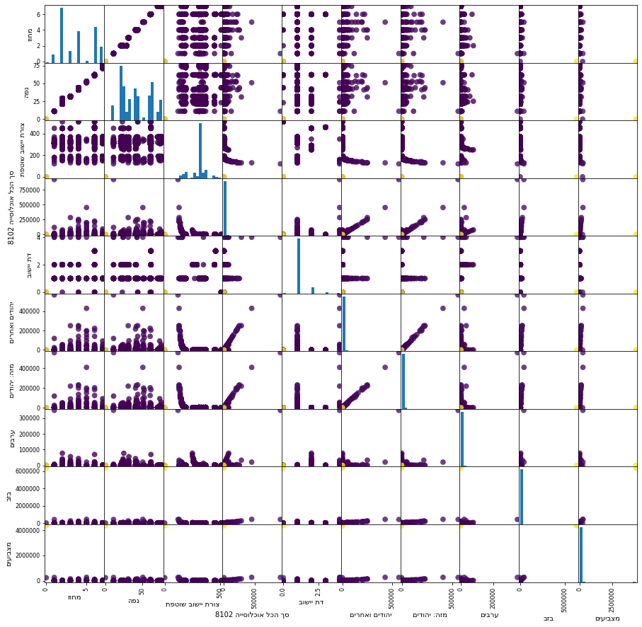

```python
df = dataFinalAdaboost.iloc[:,[1,2,3,4,5,6,7,8,9,10]]
df = dffeaturesReverse(df)

y =  dataFinalAdaboost.iloc[:,22]
pd.plotting.scatter_matrix(df, c=y, figsize=(15, 15),
                           marker='o', hist_kwds={'bins': 20}, s=60,
                           alpha=.8)
plt.show()
```

```
C:\Users\Koresh roi\Anaconda3\lib\site-packages\sklearn\model_selection\_search.py:814: DeprecationWarning: The default of the `iid` parameter will change from True to False in version 0.22 and will be removed in 0.24. This will change numeric results when test-set sizes are unequal.
  DeprecationWarning)
```

```
Best Parameters:
 {'learning_rate': 0.001, 'n_estimators': 100, 'random_state': 50}
```

```
C:\Users\Koresh roi\Anaconda3\lib\site-packages\sklearn\model_selection\_search.py:814: DeprecationWarning: The default of the `iid` parameter will change from True to False in version 0.22 and will be removed in 0.24. This will change numeric results when test-set sizes are unequal.
  DeprecationWarning)
```

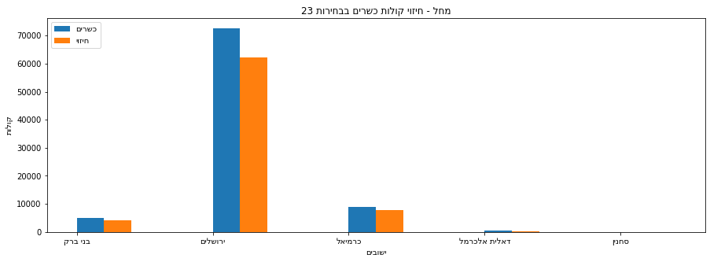

|  | שם ישוב | מחל | חיזוי מחל |
| --- | --- | --- | --- |
| 196 | בני ברק | 4951 | 4229 |
| 493 | ירושלים | 72601 | 62089 |
| 606 | כרמיאל | 8879 | 7804 |
| 321 | דאלית אלכרמל | 407 | 160 |
| 866 | סחנין | 39 | 54 |

```python
dfloc = vote23Adaboost.iloc[[196,493,606,321,866] , [2,5,7,8]]

X = vote21Adaboost.iloc[:, [2,5,7,8]]
y = vote21Adaboost.iloc[:, 22]
trainDataRegressoer, testDataRegressoer, trainTargetRegressoer, testTargetRegressoer = train_test_split(X, y, test_size=0.3, shuffle=True, random_state=1)

gsADB.fit(trainDataRegressoer,trainTargetRegressoer)
ADB_best = gsADB.best_estimator_
print("Best Parameters:\n", gsADB.best_params_)
ADB_best.predict(vote22Adaboost.iloc[:, [2,5,7,8]])

X = dataFinalAdaboost.iloc[:, [2,5,7,8]]
y = dataFinalAdaboost.iloc[:, 22]
gsADB.fit(X,y)
ADB_best = gsADB.best_estimator_
prediction_Forest = ADB_best.predict(dfloc)

# round the prediction of number of voters
predictionLikodAfterRounding = []
for i in prediction_Forest:
    predictionLikodAfterRounding.append(int(round(i)))
likod["חיזוי מחל"] = predictionLikodAfterRounding

likodOriginalScore = likod.loc[:, "מחל"]
likodPredictScore = likod.loc[:, "חיזוי מחל"]

# creating the graph with real votes and prediction in election 23
x = np.arange(5)
plt.rcParams["figure.figsize"] = (15,5)
settelmentsLikod=[]
for i in likod.iloc[:,0]:
    settelmentsLikod.append(reverse(i))

plt.title('23 תוריחבב םירשכ תולוק יוזיח - לחמ')
plt.xlabel('םיבושי')
plt.ylabel('תולוק')
plt.grid(linestyle=" ")
plt.xticks(range(0,len(settelmentsLikod)), settelmentsLikod)
plt.bar(x, list(likodOriginalScore),  width=0.20, label = 'םירשכ', align='edge')
plt.bar(x+ 0.20, list(likodPredictScore),  width=0.20, label = 'יוזיח', align='edge')
plt.legend(loc = 'upper left')
plt.show()

likod
```

## H-areshima H-meshotefet - V'daam - Joint List party

Section to predict the v'adaam (Joint list party) voters on the settelments in the requirements.

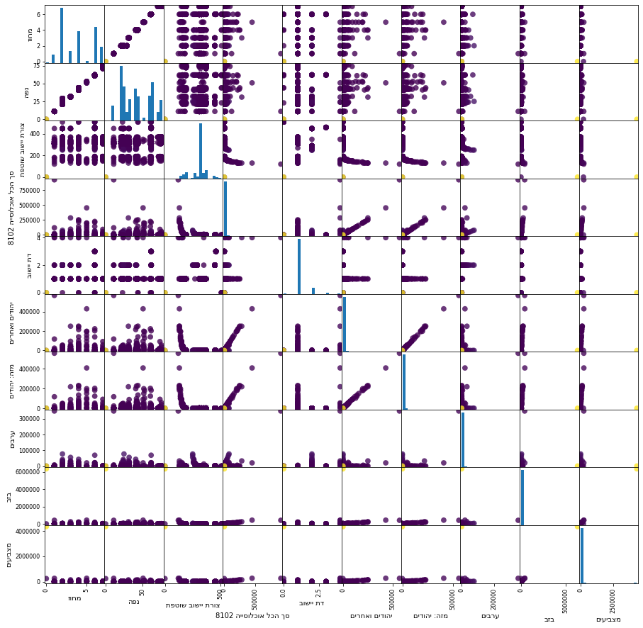

```python
df = dataFinalAdaboost.iloc[:,[1,2,3,4,5,6,7,8,9,10]]
df = dffeaturesReverse(df)

y =  dataFinalAdaboost.iloc[:,19]
pd.plotting.scatter_matrix(df, c=y, figsize=(15, 15),
                           marker='o', hist_kwds={'bins': 20}, s=60,
                           alpha=.8)
plt.show()
```

```
C:\Users\Koresh roi\Anaconda3\lib\site-packages\sklearn\model_selection\_search.py:814: DeprecationWarning: The default of the `iid` parameter will change from True to False in version 0.22 and will be removed in 0.24. This will change numeric results when test-set sizes are unequal.
  DeprecationWarning)
```

```
Best Parameters:
 {'learning_rate': 0.01, 'n_estimators': 100, 'random_state': 50}
```

```
C:\Users\Koresh roi\Anaconda3\lib\site-packages\sklearn\model_selection\_search.py:814: DeprecationWarning: The default of the `iid` parameter will change from True to False in version 0.22 and will be removed in 0.24. This will change numeric results when test-set sizes are unequal.
  DeprecationWarning)
```

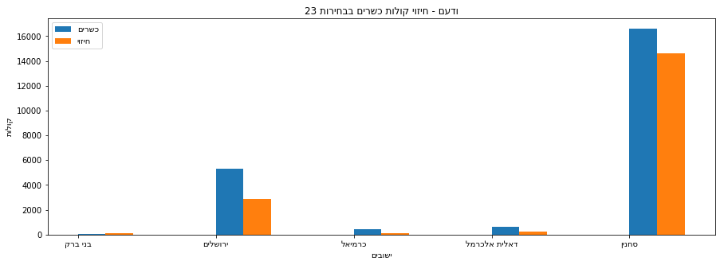

|  | שם ישוב | ודעם | חיזוי הרשימה המשותפת |
| --- | --- | --- | --- |
| 196 | בני ברק | 22 | 91 |
| 493 | ירושלים | 5321 | 2864 |
| 606 | כרמיאל | 468 | 145 |
| 321 | דאלית אלכרמל | 650 | 242 |
| 866 | סחנין | 16610 | 14610 |

```python
dfloc = vote23Adaboost.iloc[[196,493,606,321,866] , [4,5,6,8,9]]

X = vote21Adaboost.iloc[:, [4,5,6,8,9]]
y = vote21Adaboost.iloc[:, 19]
trainDataRegressoer, testDataRegressoer, trainTargetRegressoer, testTargetRegressoer = train_test_split(X, y, test_size=0.3, shuffle=True, random_state=1)

gsADB.fit(trainDataRegressoer,trainTargetRegressoer)
ADB_best = gsADB.best_estimator_
print("Best Parameters:\n", gsADB.best_params_)
ADB_best.predict(vote22Adaboost.iloc[:, [4,5,6,8,9]])

X = dataFinalAdaboost.iloc[:, [4,5,6,8,9]]
y = dataFinalAdaboost.iloc[:, 19]
gsADB.fit(X,y)
ADB_best = gsADB.best_estimator_
prediction_Forest = ADB_best.predict(dfloc)

# round the prediction of number of voters
predictionMeshotefetAfterRounding = []
for i in prediction_Forest:
    predictionMeshotefetAfterRounding.append(int(round(i)))
Meshotefet["חיזוי הרשימה המשותפת"] = predictionMeshotefetAfterRounding

MeshotefetOriginalScore = Meshotefet.loc[:, "ודעם"]
MeshotefetPredictScore = Meshotefet.loc[:, "חיזוי הרשימה המשותפת"]

# creating the graph with real votes and prediction in election 23
x = np.arange(5)
plt.rcParams["figure.figsize"] = (15,5)
settelmentsMeshotefet=[]
for i in Meshotefet.iloc[:,0]:
    settelmentsMeshotefet.append(reverse(i))

plt.title('23 תוריחבב םירשכ תולוק יוזיח - םעדו')
plt.xlabel('םיבושי')
plt.ylabel('תולוק')
plt.grid(linestyle=" ")
plt.xticks(range(0,len(settelmentsMeshotefet)), settelmentsMeshotefet)
plt.bar(x, list(MeshotefetOriginalScore),  width=0.20, label = 'םירשכ', align='edge')
plt.bar(x+ 0.20, list(MeshotefetPredictScore),  width=0.20, label = 'יוזיח', align='edge')
plt.legend(loc = 'upper left')
plt.show()

Meshotefet
```

## P-ha - Blue & White party

Section to predict the pha (Blue & white party) voters on the settelments in the requirements.

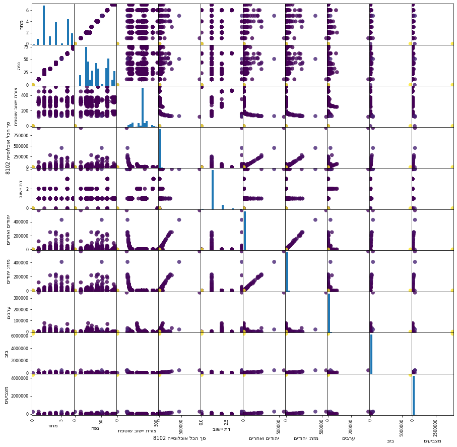

```python
df = dataFinalAdaboost.iloc[:,[1,2,3,4,5,6,7,8,9,10]]
df = dffeaturesReverse(df)

y =  dataFinalAdaboost.iloc[:,23]
pd.plotting.scatter_matrix(df, c=y, figsize=(15, 15),
                           marker='o', hist_kwds={'bins': 20}, s=60,
                           alpha=.8)
plt.show()
```

```
C:\Users\Koresh roi\Anaconda3\lib\site-packages\sklearn\model_selection\_search.py:814: DeprecationWarning: The default of the `iid` parameter will change from True to False in version 0.22 and will be removed in 0.24. This will change numeric results when test-set sizes are unequal.
  DeprecationWarning)
```

```
Best Parameters:
 {'learning_rate': 0.001, 'n_estimators': 50, 'random_state': 50}
```

```
C:\Users\Koresh roi\Anaconda3\lib\site-packages\sklearn\model_selection\_search.py:814: DeprecationWarning: The default of the `iid` parameter will change from True to False in version 0.22 and will be removed in 0.24. This will change numeric results when test-set sizes are unequal.
  DeprecationWarning)
```

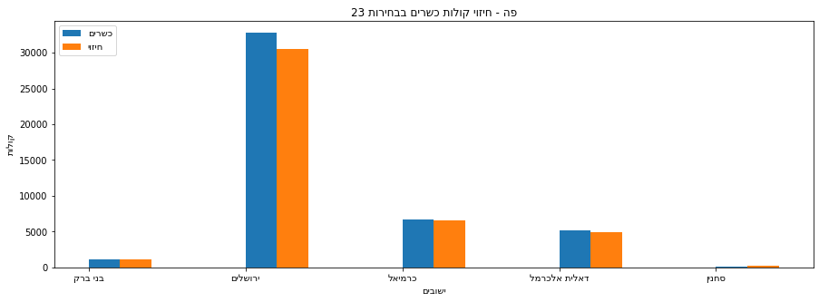

|  | שם ישוב | פה | חיזוי פה |
| --- | --- | --- | --- |
| 196 | בני ברק | 1133 | 1074 |
| 493 | ירושלים | 32800 | 30564 |
| 606 | כרמיאל | 6627 | 6524 |
| 321 | דאלית אלכרמל | 5200 | 4860 |
| 866 | סחנין | 120 | 242 |

```python
dfloc = vote23Adaboost.iloc[[196,493,606,321,866] , [5,2,4,9,7]]

X = vote21Adaboost.iloc[:, [5,2,4,9,7]]
y = vote21Adaboost.iloc[:, 23]
trainDataRegressoer, testDataRegressoer, trainTargetRegressoer, testTargetRegressoer = train_test_split(X, y, test_size=0.3, shuffle=True, random_state=1)

# delete 1 adaBoost
gsADB.fit(trainDataRegressoer,trainTargetRegressoer)
ADB_best = gsADB.best_estimator_
print("Best Parameters:\n", gsADB.best_params_)
ADB_best.predict(vote22Adaboost.iloc[:, [5,2,4,9,7]])

X = dataFinalAdaboost.iloc[:, [5,2,4,9,7]]
y = dataFinalAdaboost.iloc[:, 23]
gsADB.fit(X,y)
ADB_best = gsADB.best_estimator_
prediction_Forest = ADB_best.predict(dfloc)

# round the prediction of number of voters
predictionkaholLavanAfterRounding = []
for i in prediction_Forest:
    predictionkaholLavanAfterRounding.append(int(round(i)))
kaholLavan["חיזוי פה"] = predictionkaholLavanAfterRounding

kaholLavanOriginalScore = kaholLavan.loc[:, "פה"]
kaholLavanPredictScore = kaholLavan.loc[:, "חיזוי פה"]

# creating the graph with real votes and prediction in election 23
x = np.arange(5)
plt.rcParams["figure.figsize"] = (15,5)
settelmentskaholLavan=[]
for i in likod.iloc[:,0]:
    settelmentskaholLavan.append(reverse(i))

plt.title('23 תוריחבב םירשכ תולוק יוזיח - הפ')
plt.xlabel('םיבושי')
plt.ylabel('תולוק')
plt.grid(linestyle=" ")
plt.xticks(range(0,len(settelmentskaholLavan)), settelmentskaholLavan)
plt.bar(x, list(kaholLavanOriginalScore),  width=0.20, label = 'םירשכ', align='edge')
plt.bar(x+ 0.20, list(kaholLavanPredictScore),  width=0.20, label = 'יוזיח', align='edge')
plt.legend(loc = 'upper left')
plt.show()

kaholLavan
```

# Question 6

### prediction - which settelement need supervision

- Prediction Time: 1 week before election 23
- Table Time: 1 dayafter the election 23

In this section, after checking adaboost, random forest and meanshift we figured the best model to predict the most aqurate prediction is Decision Tree model.

- On each election we will check the ration between the number of voters in each settelement with the invalid votes.
- we will determine the raf for each election and calculate which settelement ratio is under that bar.
- we will determine the bar by the 250th location settelement. we will tell the goverment the top 250 settelement who need supervision and let them decide which they want to place supervisors. This way we wont give lower number of settelement. Better to give more then less settlments.
- becuase we have small and large settelement we divided the number of voters by sqrt (שורש) so the largest settelement will get more score then the smaller ones.
- Train phase: tרain the model on election 21 and check the prediction on election 22. after that we will train again our model on the avg votes data in election 21 + 22. when we finish with this step we will try to predict the supervition on election 23.
- because we dont have any details on election 23, we will use onnly demographich features.

###### Workflow:

1) Firstly, we figured which features will gain the most in our task. We decided to take: "בזב", "ערבים", "יהודים ואחרים", "דת"

- becuase we predict a future election results we cant use features that have direct coralletion for number of voters and valin or invalid feature.

2) How to calculate which settelement need suppervition and which dont:

- To do so, we iterated over our election 21, 22 and election 23 and we gave "1" to suppervition and "0" to none.
- calculation method: because we have many big citied and after figured out doing % between number of invalid votes and number of voters we missed few settelement because doing % is not accurate enough. Due to that, we decided to do the ratio between invaid votes and sqrt on the number of voters. In this way we will give more score for larger settlement over the small settlements.
- After classify all the settlements we decided to take the top 250 settelement that have the most ratio.

3) We will try to predict those 250 settlement. We were asked to give our prediction so we will give the comitee 250 settelement and will show them the top 10. In this way we can give them the option to chose which settlements the way to place suppervitions and which not to.

4) To figure which model will predict the most aqurate predictions with our features. We figured we should use decision tree.

5) After finding our best features and model, we will train the Decision Tree model with election 21 data set with the relevant features and test our model with the election 22 data set. after doing that we will train again our model with the 21+22 avg dataset to get better prediction. With this way we will get better and aqurate results to predict in election 23.

7) We will show the prediction vs. the real supervition in election 23 via a table and confusion matrix.

8) make the conclution over the settlement we predicted need supervision.

```python
vote21Inspection  = pd.read_excel('HW2_ML\\ElectionData\\Election21_With_Index_Features.xlsx')
vote21Inspection.drop(vote21Inspection.tail(1).index,inplace=True)
vote22Inspection  = pd.read_excel('HW2_ML\\ElectionData\\Election22_With_Index_Features.xlsx')
vote22Inspection.drop(vote22Inspection.tail(1).index,inplace=True)
vote23Inspection  = pd.read_excel('HW2_ML\\ElectionData\\Election23_With_Index_Features.xlsx')
vote23Inspection.drop(vote23Inspection.tail(1).index,inplace=True)
dataFinalPikohach = pd.read_excel('HW2_ML\\ElectionData\\Election21_22_AVG_With_Index_Features.xlsx')
dataFinalPikohach.drop(dataFinalPikohach.tail(1).index,inplace=True)
```

```python
# election 21 data
vote21Inspection = calculateRatio(vote21Inspection)
rafForCheckersV21 = vote21Inspection.head(250)[-1:]["יחס סופי"].iloc[0]
supervisionNeed(vote21Inspection, rafForCheckersV21)

# election 22 data
vote22Inspection = calculateRatio(vote22Inspection)
rafForCheckersV22 = vote22Inspection.head(250)[-1:]["יחס סופי"].iloc[0]
supervisionNeed(vote22Inspection, rafForCheckersV22)

# election 21 + 22 data
dataFinalPikohach = calculateRatio(dataFinalPikohach)
rafForCheckers = dataFinalPikohach.head(250)[-1:]["יחס סופי"].iloc[0]
supervisionNeed(dataFinalPikohach,rafForCheckers)

# election 23 data
vote23Inspection = calculateRatio(vote23Inspection)
rafForCheckersV23 = vote23Inspection.head(250)[-1:]["יחס סופי"].iloc[0]
supervisionNeed(vote23Inspection, rafForCheckersV23)
```

```python
dfloc = vote23Inspection.iloc[: , [5,6,8,9]]

X = vote21Inspection.iloc[:, [5,6,8,9]]
y = vote21Inspection.iloc[:, -1]
trainDataRegressoer, testDataRegressoer, trainTargetRegressoer, testTargetRegressoer = train_test_split(X, y, test_size=0.3, shuffle=True, random_state=1)
param_grid ={'criterion':['gini'], 'max_depth':range(2,10), 'min_samples_split':range(2,10)}
tree = GridSearchCV(DecisionTreeClassifier(random_state=1), param_grid, cv=7, scoring='accuracy')
# fit the data on election 21
tree.fit(trainDataRegressoer, trainTargetRegressoer)
treeBestModel = tree.best_estimator_
# predict election 22
treeBestModel.predict(vote22Inspection.iloc[:, [5,6,8,9]])

X = dataFinalPikohach.iloc[:,[5,6,8,9]]
y = dataFinalPikohach.iloc[:, -1]
# fit the data on election 21 + 22 avg.
tree.fit(X,y)
print("Best Estimator:\n", treeBestModel)
```

```
Best Estimator:
 DecisionTreeClassifier(class_weight=None, criterion='gini', max_depth=3,
                       max_features=None, max_leaf_nodes=None,
                       min_impurity_decrease=0.0, min_impurity_split=None,
                       min_samples_leaf=1, min_samples_split=2,
                       min_weight_fraction_leaf=0.0, presort=False,
                       random_state=1, splitter='best')
```

```python
# predict the election 23 supervision
prediction_V23 = treeBestModel.predict(vote23Inspection.iloc[:, [5,6,8,9]])
print(np.unique(prediction_V23, return_counts = True))
metrics.accuracy_score(vote23Inspection.iloc[:,-1], prediction_V23)
```

```
(array([0, 1], dtype=int64), array([999, 211], dtype=int64))
```

```
0.915702479338843
```

```
[[929  32]
 [ 70 179]]
```

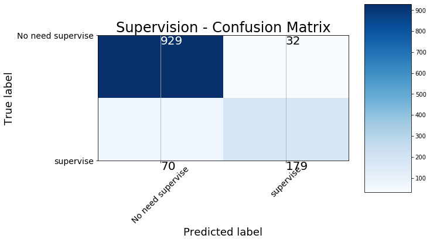

```python
from sklearn.metrics import confusion_matrix
import itertools

def plot_confusion_matrix(cm, classes,normalize=False, title='Confusion matrix', cmap="Blues"):
    """
    This function prints and plots the confusion matrix.
    Normalization can be applied by setting `normalize=True`.
    Source: http://scikit-learn.org/stable/auto_examples/model_selection/plot_confusion_matrix.html
    """
    print(cm)

    plt.figure(figsize = (10, 10))
    plt.imshow(cm, interpolation='nearest', cmap=cmap)
    plt.title(title, size = 24)
    plt.colorbar(aspect=4)
    tick_marks = np.arange(len(classes))
    plt.xticks(tick_marks, classes, rotation=45, size = 14)
    plt.yticks(tick_marks, classes, size = 14)

    fmt = '.2f' if normalize else 'd'
    thresh = cm.max() / 2.

    # Labeling the plot
    for i, j in itertools.product(range(cm.shape[0]), range(cm.shape[1])):
        plt.text(j, i, format(cm[i, j], fmt), fontsize = 20,
                 verticalalignment="top",
                 color="white" if cm[i, j] > thresh else "black")

    plt.grid(None)
    plt.tight_layout()
    plt.ylabel('True label', size = 18)
    plt.xlabel('Predicted label', size = 18)

# compare the real supervision vs the prediction
confusion_matrix = confusion_matrix(vote23Inspection.iloc[:,-1], prediction_V23)
plot_confusion_matrix(confusion_matrix, classes = ['No need supervise', 'supervise'], title = 'Supervision - Confusion Matrix')
```

```python
vote23Inspection["חיזוי פיקוח"] = prediction_V23
vote23Inspection.drop(vote23Inspection[vote23Inspection['שם ישוב'] == "מעטפות חיצוניות"].index, inplace = True)
# show the top 10 settlements which need supervision
display(vote23Inspection.head(10))
dataFinalPikohach["חיזוי פיקוח"] = prediction_V23
dataFinalPikohach.drop(dataFinalPikohach.tail(1).index,inplace=True)
dataFinalPikohach = dataFinalPikohach.loc[(dataFinalPikohach[['חיזוי פיקוח']] != 0).all(axis=1)]
dataFinalPikohach = dataFinalPikohach.iloc[:,[0,1,3,5,-2,-1]]
```

|  | שם ישוב | מחוז | נפה | צורת יישוב שוטפת | סך הכל אוכלוסייה 2018 | דת יישוב | יהודים ואחרים | מזה: יהודים | ערבים | בזב | ... | נק | ףז | ץ | ק | קי | קך | קץ | יחס סופי | פיקוח | חיזוי פיקוח |
| --- | --- | --- | --- | --- | --- | --- | --- | --- | --- | --- | --- | --- | --- | --- | --- | --- | --- | --- | --- | --- | --- |
| 196 | בני ברק | 5 | 52 | 140 | 198863 | 1 | 198799 | 197439 | 64 | 111344 | ... | 1 | 9 | 6 | 1 | 4 | 3 | 9 | 3.172016 | 1 | 1 |
| 493 | ירושלים | 1 | 11 | 120 | 919438 | 4 | 569866 | 555845 | 349572 | 415991 | ... | 12 | 77 | 19 | 21 | 18 | 29 | 79 | 3.167371 | 1 | 1 |
| 129 | באר שבע | 6 | 62 | 130 | 209002 | 1 | 203622 | 181644 | 5380 | 161968 | ... | 9 | 26 | 9 | 35 | 19 | 16 | 61 | 2.481755 | 1 | 1 |
| 653 | מודיעין עילית | 7 | 74 | 150 | 92406 | 1 | 92381 | 90449 | 25 | 28796 | ... | 1 | 3 | 0 | 0 | 1 | 1 | 1 | 2.412803 | 1 | 1 |
| 405 | חיפה | 3 | 31 | 130 | 283640 | 4 | 250943 | 217360 | 32697 | 249627 | ... | 17 | 46 | 35 | 51 | 17 | 19 | 58 | 2.262545 | 1 | 1 |
| 114 | אשדוד | 6 | 61 | 130 | 224628 | 1 | 224328 | 201388 | 300 | 179046 | ... | 11 | 32 | 22 | 20 | 9 | 10 | 17 | 2.017638 | 1 | 1 |
| 1185 | תל אביב יפו | 5 | 51 | 130 | 451523 | 4 | 431149 | 407198 | 20374 | 434208 | ... | 16 | 63 | 32 | 33 | 14 | 14 | 31 | 1.933182 | 1 | 1 |
| 230 | בת ים | 5 | 53 | 140 | 128774 | 1 | 127991 | 102268 | 783 | 124576 | ... | 8 | 14 | 10 | 22 | 4 | 11 | 22 | 1.928196 | 1 | 1 |
| 857 | נתניה | 4 | 41 | 130 | 217244 | 1 | 216709 | 197860 | 535 | 184613 | ... | 15 | 22 | 18 | 26 | 7 | 25 | 32 | 1.914144 | 1 | 1 |
| 1082 | רמלה | 4 | 43 | 150 | 75538 | 4 | 57680 | 53975 | 17858 | 55672 | ... | 7 | 6 | 6 | 12 | 5 | 5 | 8 | 1.896012 | 1 | 1 |

10 rows × 47 columns

```python
# Becuase we are 1 week before the election we will use the avg data from election 21 + 22 to make our conclutions.
# we know the number of the arab and jewish settlments from election 23 becuase its demographic feature.
jewish = vote23Inspection['דת יישוב'].value_counts()[1]
arabs = vote23Inspection['דת יישוב'].value_counts()[2]
c = Counter(dataFinalPikohach['צורת יישוב שוטפת'])
print ("Tzorat Yeshov: ", c.most_common(10))
c = Counter(dataFinalPikohach['דת יישוב'])
if (c.most_common(4)[0][1]/jewish) > (c.most_common(4)[1][1]/arabs):
    print("There are ","{:.2f}".format( c.most_common(4)[0][1]/jewish), "% from Jewish settlments who need supervision" )
else:
    print("There are ","{:.2f}".format( c.most_common(4)[1][1]/arabs), "% from Arabs settlments who need supervision" )
c = Counter(dataFinalPikohach['מחוז'])
print ("Mahoz : ", c.most_common(7))
```

```
Tzorat Yeshov:  [(160, 32), (310, 21), (270, 20), (150, 16), (260, 15), (280, 15), (450, 13), (290, 12), (170, 9), (460, 9)]
There are  0.61 % from Arabs settlments who need supervision
Mahoz :  [(2, 67), (4, 44), (6, 42), (3, 28), (7, 10), (5, 10), (1, 9)]
```